# Coaching

Aside from research, my friends know that the sport of lacrosse is a big part of my life. So, here’s a bit of that life:

[figure not shown]

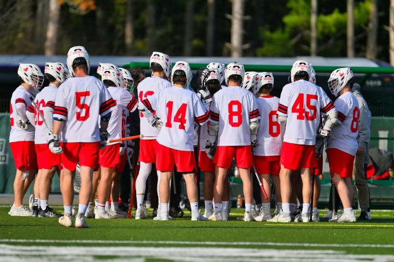

*CUFLA National Championship Final, 2023*

[figure not shown]

*U17 Canadian National Field Lacrosse Championship, 2024*

Here’s a map of the geographic ties I’ve made through lacrosse*:

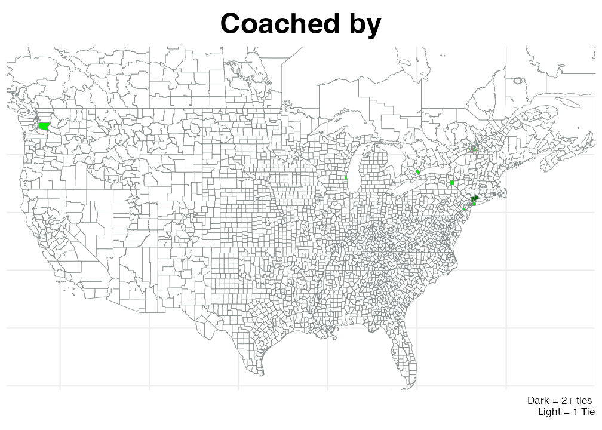

*<sub><sup>There are two key omissions in Australia and Belgium, due to space constraints.</sup></sub>

# Coaching Placements

Here is a list of some amazing student-athletes whom I’ve had the pleasure of coaching that went on to compete at the next level:

- **AJ Hrodey** (Edgewood-Monona Grove ’26) → Ohio Northern University [*NCAA DIII*]
- **Cullen Gustavson** (Madison Knights ’25/Madison West ’26) → Union College [*NCAA DIII*]
- **Rowe Schumacher** (Madison Knights ’25) → Milwaukee School of Engineering [*NCAA DIII*]
- **Ben Morrison Phillips** (Madison Knights ’25) → Canisius University [*NCAA DI*]
- **Cameron Lockton** (Madison Knights ’25) → Illinois Wesleyan University [*NCAA DIII*]
- **Cristopher Discua** (Westhill HS ’25) → Manhattanville University [*NCAA DIII*]
- **Olivier Tellier** (Team QC U17 ’24) → University of Ottawa [*CUFLA*]
- **Jared Boyd** (Westhill HS ’24) → University of Bridgeport [*NCAA DII*]
- **Jeremiah Saint Valiere** (Westhill HS ’23) → Dean College [*NCAA DIII*]
- **James Leydon** (Westhill HS ’23) → Union College [*NCAA DIII*]
- **Jack Ladenheim** (Dawson College ’23) → Dalhousie University [*MUFLL*]
- **Julia Ibelings** (Dawson College ’23) → University of Toronto [*OUA*]
- **Ashton Benkwitt** (Westhill HS ’22) → Delaware Valley University [*NCAA DIII*]
- **Nasir Thornton** (Westhill HS ’22) → Norfolk State University [*NCL*]

*<sub><sup>The term “placements” is used very loosely here. The athletes are the ones who put in the work.</sup></sub>

# Coaching CV

I’m off the (coaching) job market!

I’m currently serving as the Defensive Coordinator for the Edgewood–Monona Grove Co-op High School lacrosse team (formerly the Madison Knights) and a U12 coach (Field/Box) for Fluid Lacrosse.

Below is a brief CV of my coaching/athletic history. To discuss potential coaching and training opportunities or to just talk ball, feel free to reach out to me at my personal email: **johndanielshicks[at]gmail[dot]com**

[interactive chart not shown]